# Lab 6 - ANSWER KEY

**Please see below for answers to all parts of Lab 6. Note, I provide you one way to do the code - there are others. That said, all code relates to the topic of the week - tidyverse.**

**Scoring Summary**

- 10 points = submission to Github
  - **You must upload the QMD and HTML for full credit**
- 5 points = Code that runs (no errors, all chunks visible)
- 5 points = Correct answers. (Regardless of code)

# Answers

**Remember to Set Seed**

```r
library(tidyverse)
set.seed(1991)
```

## Part 1

### Exercise 1

Use `rnorm()` to simulate 1,000 exam scores from a population with a mean of 75 and standard deviation of 10. Plot a histogram of your results and overlay a density curve. Does the shape look like what you’d expect? What happens if you change n to 50?

```r
n <- 1000          # change to 50 to see the difference
mu <- 75
sigma <- 10
```

```r
dat <- rnorm(n, mu, sigma)
head(dat)
```

```
[1] 64.66235 52.87979 83.16665 84.48383 71.84035 77.34035
```

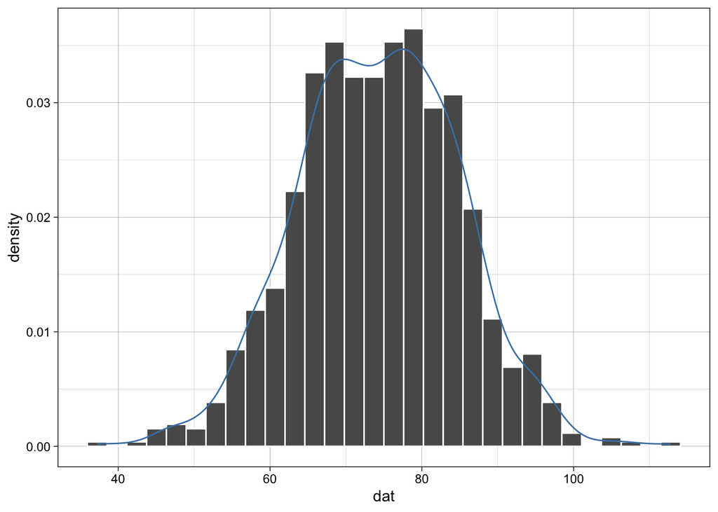

```r
ggplot() + geom_histogram(mapping = aes(x = dat, y = after_stat(density)), color = "white") + geom_density(mapping = aes(dat), color = "steelblue") + theme_linedraw()
```

```r
n <- 50          # change to 50 to see the difference
mu <- 75
sigma <- 10
```

```r
dat <- rnorm(n, mu, sigma)
head(dat)
```

```
[1] 85.96284 51.23506 71.06796 76.85135 83.86399 62.13131
```

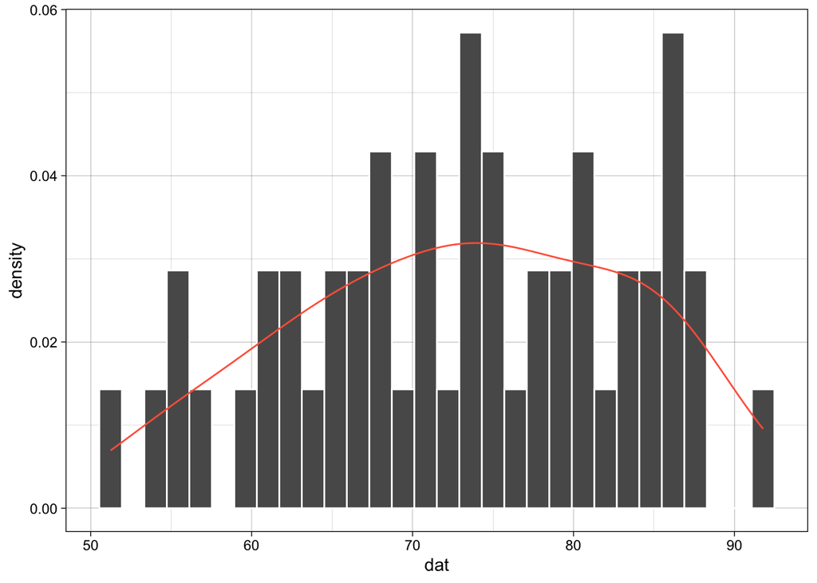

```r
ggplot() + geom_histogram(mapping = aes(x = dat, y = after_stat(density)), color = "white") + geom_density(mapping = aes(dat), color = "tomato") + theme_linedraw()
```

### Exercise 2

Use `dnorm()` to compute the density of the normal distribution at x = 70, 75, and 80, given mean = 75 and sd = 10. Plot the full density curve from x = 40 to x = 110. Which value has the highest density and why?

**75 has the highest density because it is the mean / mode value or area with most probability mass.**

```r
dnorm(70, mean = 75, sd = 10)
```

```
[1] 0.03520653
```

```r
dnorm(75, mean = 75, sd = 10)
```

```
[1] 0.03989423
```

```r
dnorm(80, mean = 75, sd = 10)
```

```
[1] 0.03520653
```

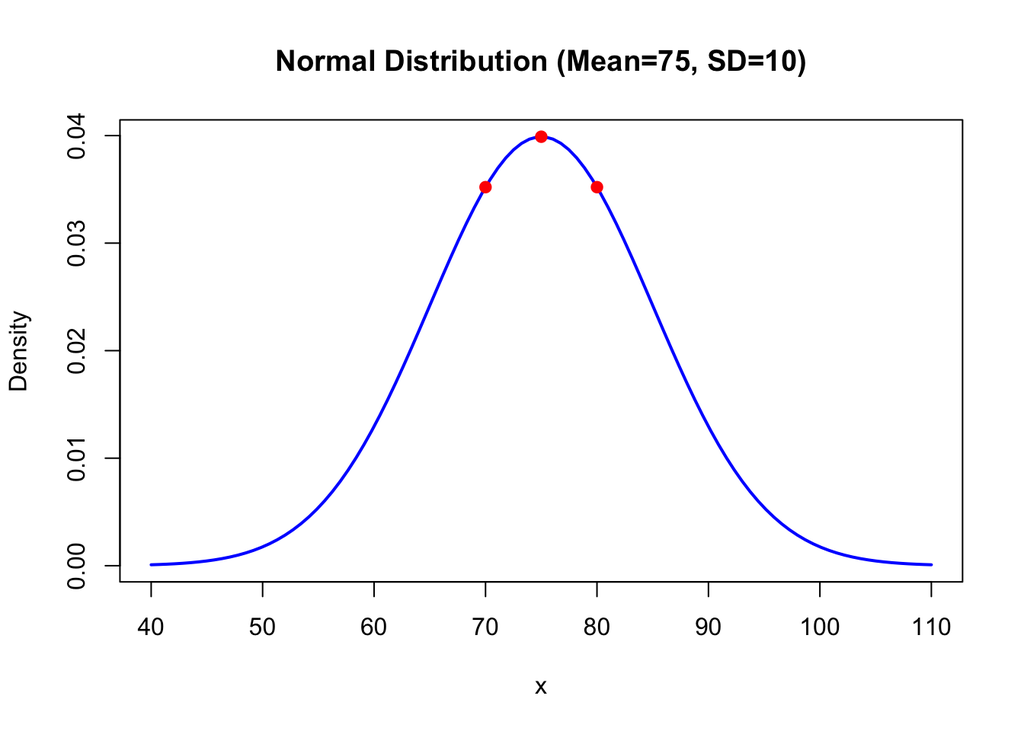

```r
# Define the range and parameters
x <- seq(40, 110, length.out = 100)
y <- dnorm(x, mean = 75, sd = 10)

# Create the plot
plot(x, y, type = "l", lwd = 2, col = "blue",
     main = "Normal Distribution (Mean=75, SD=10)",
     xlab = "x", ylab = "Density")

# Add points for the specific values
points(c(70, 75, 80), dnorm(c(70, 75, 80), 75, 10), col = "red", pch = 19)
```

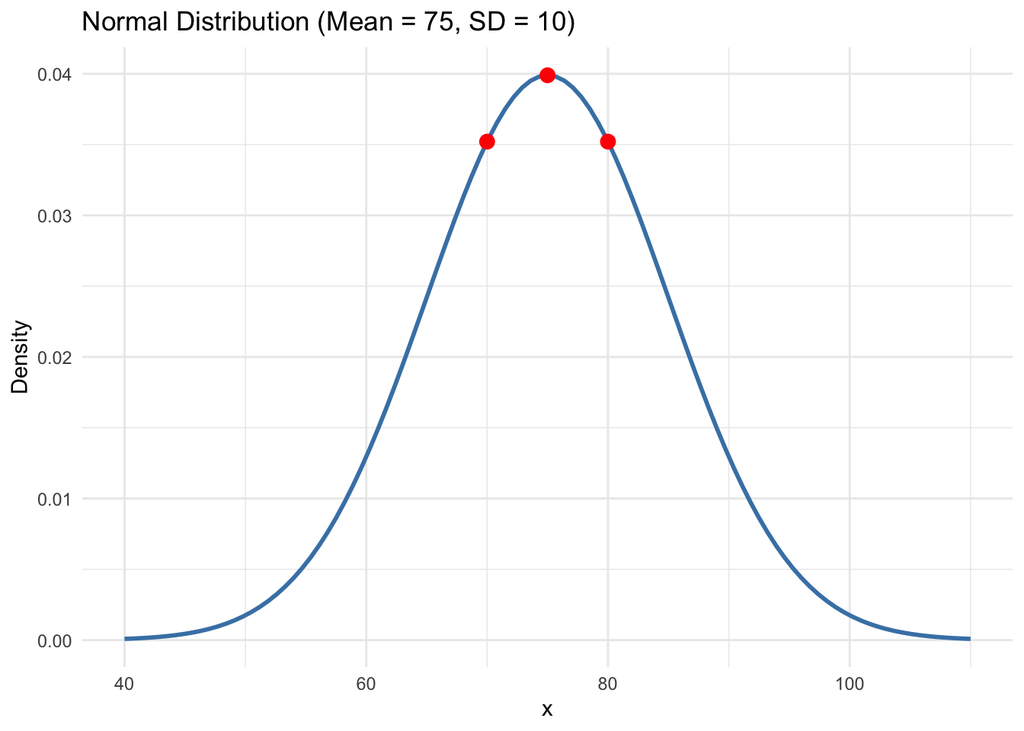

```r
# Create a data frame for the x-axis range
df <- data.frame(x = c(40, 110))

# Plot using ggplot
ggplot(df, aes(x = x)) +
  stat_function(fun = dnorm, args = list(mean = 75, sd = 10), color = "steelblue", linewidth = 1) +
  geom_point(data = data.frame(x = c(70, 75, 80), y = dnorm(c(70, 75, 80), 75, 10)),
             aes(x = x, y = y), color = "red", size = 3) +
  labs(title = "Normal Distribution (Mean = 75, SD = 10)",
       y = "Density", x = "x") +
  theme_minimal()
```

### Exercise 3

A standardized test has scores that are normally distributed with mean = 500 and sd = 100.

- What proportion of students scored below 450?

```r
pnorm(450, mean = 500, sd = 100)
```

```
[1] 0.3085375
```

- What proportion scored above 650?

```r
pnorm(650, mean = 500, sd = 100, lower.tail = FALSE)
```

```
[1] 0.0668072
```

- What proportion scored between 400 and 600?

```r
pnorm(600, 500, 100) - pnorm(400, 500, 100)
```

```
[1] 0.6826895
```

## Part 2

### Exercise 5

A multiple choice quiz has 20 questions, each with 4 answer choices. A student guesses randomly on every question.

- Use `dbinom()` to find the probability of getting exactly 5 correct.
- Plot the full probability mass function (all outcomes 0–20). What does the shape tell you?

**Getting exactly 5 correct.**

```r
dbinom(5, size = 20, prob = 0.25)
```

```
[1] 0.2023312
```

**Plot.**

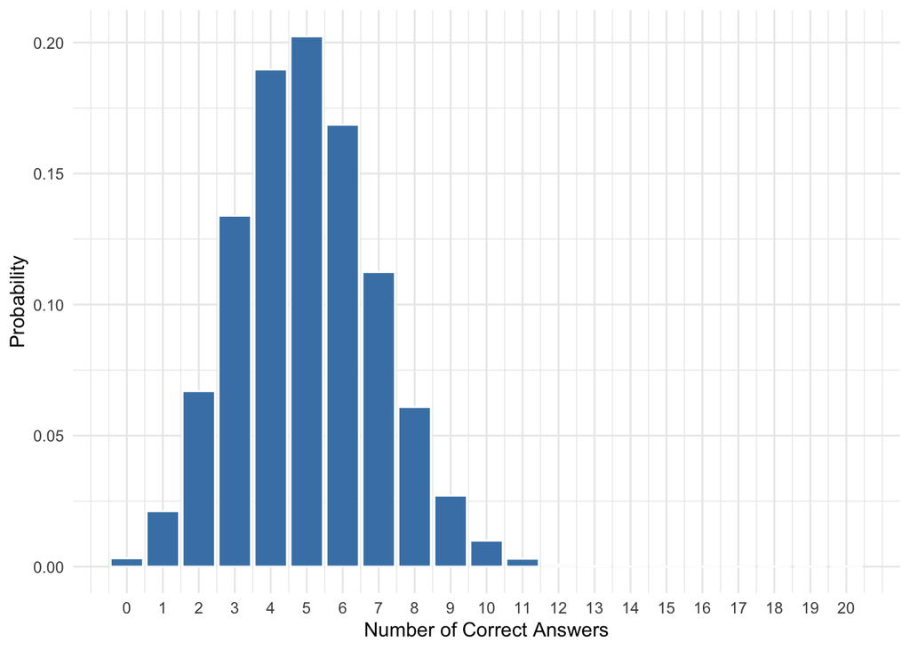

```r
# Create data for all possible outcomes (0 to 20)
quiz_data <- data.frame(
  correct = 0:20,
  prob = dbinom(0:20, size = 20, prob = 0.25)
)

# Plot the PMF
ggplot(quiz_data, aes(x = correct, y = prob)) +
  geom_col(fill = "steelblue", color = "white") +
  scale_x_continuous(breaks = 0:20) +
  labs(
       x = "Number of Correct Answers",
       y = "Probability") +
  theme_minimal()
```

*The probablity of success is low at 25% (1/4) if one guesses randomly. So, the mass is centered at this likelihood 5/20 or 25%.

### Exercise 6

Using `pbinom()`.

- What is the probability of getting 8 or fewer correct by guessing?

```r
pbinom(8, size = 20, prob = 0.25)
```

```
[1] 0.9590748
```

- What is the probability of getting more than 10 correct?

```r
pbinom(10, size = 20, prob = 0.25, lower.tail = FALSE)
```

```
[1] 0.003942142
```

- Would getting 12 correct be surprising? Use a probability to support your answer.

```r
pbinom(10, size = 20, prob = 0.25, lower.tail = FALSE)
```

```
[1] 0.003942142
```

## Part 3

### Exercise 7

A hospital emergency room receives an average of 8 patients per hour. This means lambda = 8 in the `Poisson` functions. (e.g., `dpois(x = COUNT, lambda = 8)`).

- Use `dpois()` to find the probability of receiving exactly 8 patients in a given hour.

```r
dpois(x = 8, lambda = 8)
```

```
[1] 0.1395865
```

- Find the probability of receiving fewer than 5 patients using `ppois().`

```r
ppois(q = 4, lambda = 8)
```

```
[1] 0.0996324
```

- Simulate 500 hours of arrivals using `rpois()` and plot the result.

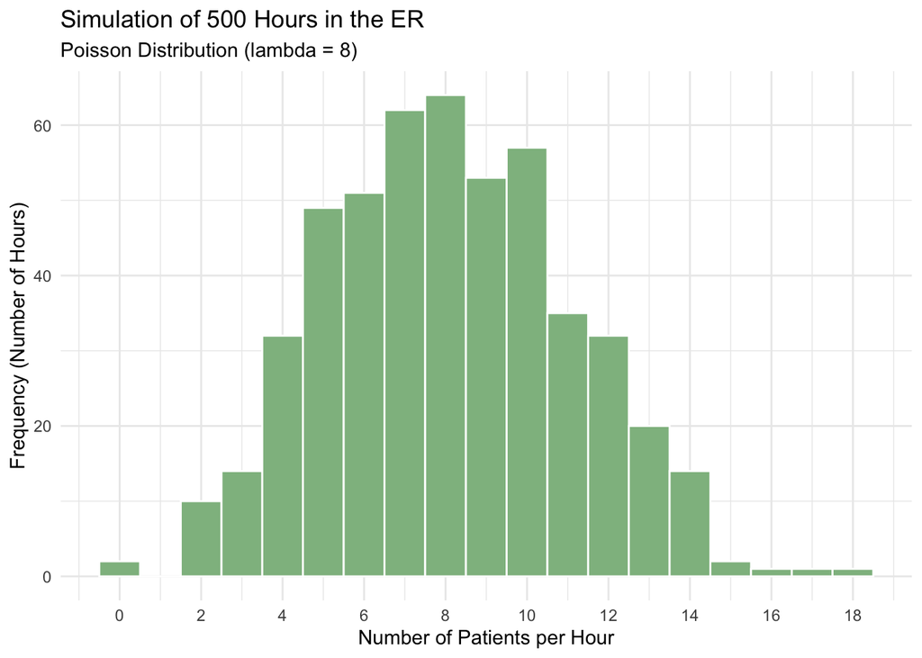

```r
sim_arrivals <- rpois(n = 500, lambda = 8)

# Convert to data frame for plotting
df_sim <- data.frame(arrivals = sim_arrivals)

# Plot the results
ggplot(df_sim, aes(x = arrivals)) +
  geom_histogram(binwidth = 1, fill = "darkseagreen", color = "white") +
  scale_x_continuous(breaks = seq(0, 20, 2)) +
  labs(title = "Simulation of 500 Hours in the ER",
       subtitle = "Poisson Distribution (lambda = 8)",
       x = "Number of Patients per Hour",
       y = "Frequency (Number of Hours)") +
  theme_minimal()
```

## Part 4

### Exercise 8

A bus arrives at a stop at a uniformly random time between 0 and 30 minutes after you arrive.  
**This is the uniform distribution.**

- Use `punif()` to find the probability you wait less than 10 minutes.

```r
punif(q = 10, min = 0, max = 30)
```

```
[1] 0.3333333
```

- Use `qunif()` to find the wait time that only 25% of riders experience or less.

```r
qunif(p = 0.25, min = 0, max = 30)
```

```
[1] 7.5
```

### Exercise 9

The time between customer service calls follows an exponential distribution with a mean of 5 minutes (rate = 1/5).  
**This is the exponential distribution.**

- Use `pexp()` to find the probability the next call arrives within 3 minutes.

```r
pexp(q = 3, rate = 0.2)
```

```
[1] 0.4511884
```

- Use `qexp()` to find the time by which 90% of calls will have arrived.

```r
qexp(p = 0.90, rate = 0.2)
```

```
[1] 11.51293
```

## Part 5: Synthesis

### Exercise 10:

Simulate 10,000 data points using a distribution of your choosing. Find the 95% interval range (probs = 0.025-0.975) of your values. Plot the histogram, overlay a density, and label the minimum and maximum of your range.

**Can have any example here as long as it includes random data generation, the quantile function, and a plot with histogram and density.

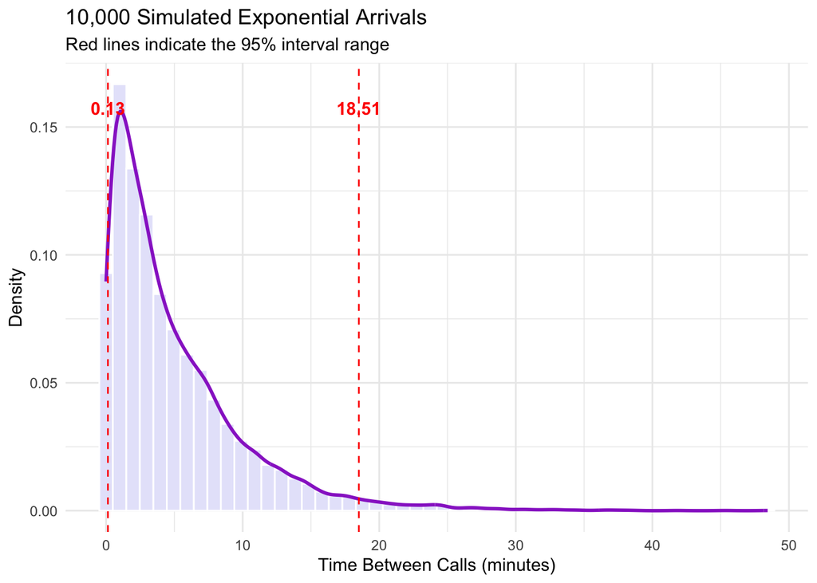

```r
data <- data.frame(time = rexp(10000, rate = 0.2))

# 2. Find the 95% interval range (2.5th and 97.5th percentiles)
interval <- quantile(data$time, probs = c(0.025, 0.975))
# 2.5%: ~0.12  |  97.5%: ~18.44

# 3. Plot
ggplot(data, aes(x = time)) +
  geom_histogram(aes(y = ..density..), bins = 50, fill = "lavender", color = "white") +
  geom_density(color = "darkorchid", size = 1) +
  geom_vline(xintercept = interval, color = "red", linetype = "dashed") +
  annotate("text", x = interval, y = 0.15, label = round(interval, 2),
           color = "red", vjust = -1, fontface = "bold") +
  labs(title = "10,000 Simulated Exponential Arrivals",
       subtitle = "Red lines indicate the 95% interval range",
       x = "Time Between Calls (minutes)", y = "Density") +
  theme_minimal()
```